# How Well Do European Polygenic Scores Work in East Asians?

A simulation study on real 1000 Genomes genotypes: C+T, LDpred2 and a multi-ancestry score

Author

Zi-Jie Liu

## Summary

Most polygenic risk score (PRS) training data come from Europeans. This study measures how much accuracy a European-trained PRS loses in East Asians, where the loss comes from, and how much a modest East Asian GWAS recovers.

## Why this matters

East Asians are about a fifth of the world’s population but a small share of GWAS participants. Taiwan Precision Medicine Initiative and Biobank Japan are closing that gap, and the practical question is the one simulated here: given a large European GWAS and a smaller East Asian one, how should a score for East Asian patients be built?

## Design

| Component | Choice |
| --- | --- |
| Genotypes | 1000 Genomes phase 3: 503 Europeans (EUR), 504 East Asians (EAS) |
| SNP set | 199,865 SNPs with MAF ≥ 5% in both ancestries, MHC removed |
| Causal architecture | h² = 0.4 in EUR, 0.5% of SNPs causal, per-allele effects correlated ρ across ancestries |
| GWAS | Summary statistics simulated from LD: β̂ = Rβ + ε, ε ~ N(0, R/N); EUR N = 100,000, EAS N = 5,000 or 20,000 |
| Scores | C+T (EUR), LDpred2-inf (EUR), LDpred2-auto (EUR), LDpred2-auto (EAS), multi-ancestry combination |
| Evaluation | Tune on half of EAS (simulated phenotypes), test on the other half against true genetic values |
| Scenarios | ρ ∈ {0.6, 0.8, 1.0} × EAS N ∈ {5,000, 20,000} × 10 replicates; plus causal-variants-untyped runs |

Simulating summary statistics from LD, instead of simulating hundreds of thousands of individuals, is the standard approach in PRS methods papers: it keeps the real LD structure of each ancestry while making a 100,000-person GWAS cheap. Accuracy is reported as R² between the score and the true genetic value, scaled to a phenotype with variance 1, so the ceiling is the heritability.

The multi-ancestry score is a weighted sum of the EUR and EAS LDpred2-auto scores, with weights fitted on the East Asian tuning half. This is the same idea as PRS-CSx’s final step.

**Link to my thesis.** LDpred2-inf is the summary-statistic form of GBLUP, the model behind my genomic selection work, so the same shrinkage machinery moves from crop varieties to human disease risk. The comparison with LDpred2-auto shows the cost of GBLUP’s “every SNP has a small effect” assumption when the trait is sparse.

## Results

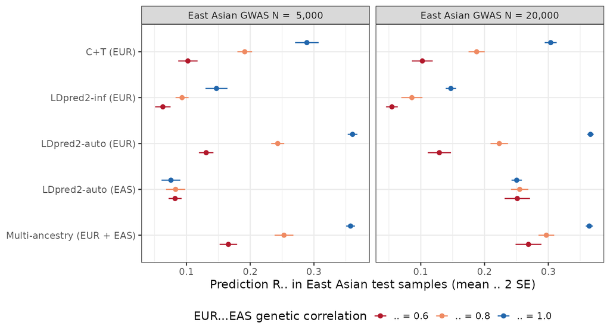

Prediction R² in East Asian test samples by method. Points are means over 10 replicates, bars ±2 SE.

East Asian prediction R², mean (SE) over 10 replicates

| Method | ρ=0.6, N_EAS= 5,000 | ρ=0.6, N_EAS=20,000 | ρ=0.8, N_EAS= 5,000 | ρ=0.8, N_EAS=20,000 | ρ=1, N_EAS= 5,000 | ρ=1, N_EAS=20,000 |
| --- | --- | --- | --- | --- | --- | --- |
| C+T (EUR) | 0.102 (0.008) | 0.102 (0.008) | 0.191 (0.006) | 0.188 (0.006) | 0.289 (0.009) | 0.304 (0.005) |
| LDpred2-inf (EUR) | 0.063 (0.006) | 0.055 (0.005) | 0.093 (0.005) | 0.086 (0.008) | 0.147 (0.009) | 0.147 (0.004) |
| LDpred2-auto (EUR) | 0.131 (0.006) | 0.129 (0.009) | 0.243 (0.005) | 0.223 (0.007) | 0.361 (0.004) | 0.366 (0.003) |
| LDpred2-auto (EAS) | 0.082 (0.005) | 0.251 (0.010) | 0.083 (0.008) | 0.255 (0.007) | 0.076 (0.007) | 0.250 (0.004) |
| Multi-ancestry (EUR + EAS) | 0.166 (0.007) | 0.269 (0.010) | 0.253 (0.007) | 0.297 (0.006) | 0.357 (0.003) | 0.364 (0.003) |

### Where the European score loses accuracy

| Causal variants | Genetic correlation ρ | EAS R² / EUR R², LDpred2-auto (EUR) |
| --- | --- | --- |
| Genotyped | 0.6 | 0.35 (0.01) |
| Genotyped | 0.8 | 0.63 (0.01) |
| Genotyped | 1.0 | 0.98 (0.01) |
| Not genotyped | 0.8 | 0.53 (0.02) |
| Not genotyped | 1.0 | 0.85 (0.03) |

Effect-size heterogeneity behaves as theory predicts: with genotyped causal variants the ratio tracks ρ² (0.36 and 0.64 for ρ = 0.6 and 0.8). When the causal variants are not on the SNP set, the score depends on tagging SNPs whose LD with the causal variant differs between Europeans and East Asians, and accuracy drops even with identical biology.

### What an East Asian GWAS adds

| ρ | EAS GWAS N | Relative R² gain over EUR LDpred2-auto |
| --- | --- | --- |
| 0.6 | 5,000 | 27% (SE 1%) |
| 0.6 | 20,000 | 114% (SE 10%) |
| 0.8 | 5,000 | 4% (SE 1%) |
| 0.8 | 20,000 | 34% (SE 3%) |
| 1.0 | 5,000 | -1% (SE 0%) |
| 1.0 | 20,000 | -1% (SE 0%) |

With ρ = 1 the East Asian data add nothing: the European GWAS already estimates the same effects more precisely. The smaller ρ, the more an ancestry-matched GWAS is worth, even at a fifth of the European sample size.

## Limitations

- 1000 Genomes has about 500 people per ancestry, so LD is estimated with noise. The same samples provide LD and test genotypes; phenotypes in the test half are never used for training.
- LD is block-diagonal over 2 Mb blocks for both simulation and fitting; real data add reference-panel mismatch.
- The SNP set is 200,000 common SNPs, not the ~1 million HapMap3 variants used in practice.

## Reproduce

```bash
bash R/00_prepare_genotypes.sh     # needs data-raw/chr*.bed from data-raw/get_chr.sh
Rscript R/01_ld.R                  # EUR and EAS LD references
bash R/run_simulations.sh          # 80 replicates
Rscript R/03_summarise.R
quarto render report.qmd
```